```python
import pandas as pd
import matplotlib.pyplot as plt
import seaborn as sns
import numpy as np

from sklearn import model_selection, metrics
from sklearn.preprocessing import RobustScaler
from sklearn.linear_model import LogisticRegression
from sklearn.neighbors import KNeighborsClassifier
from sklearn.ensemble import RandomForestClassifier
```

# 1. Exploratory Data Analysis

```python
# Import the dataset and get an overview
df = pd.read_csv("Churn_Modelling.csv")
df.head()
```

|  | RowNumber | CustomerId | Surname | CreditScore | Geography | Gender | Age | Tenure | Balance | NumOfProducts | HasCrCard | IsActiveMember | EstimatedSalary | Exited |
| --- | --- | --- | --- | --- | --- | --- | --- | --- | --- | --- | --- | --- | --- | --- |
| 0 | 1 | 15634602 | Hargrave | 619 | France | Female | 42 | 2 | 0.00 | 1 | 1 | 1 | 101348.88 | 1 |
| 1 | 2 | 15647311 | Hill | 608 | Spain | Female | 41 | 1 | 83807.86 | 1 | 0 | 1 | 112542.58 | 0 |
| 2 | 3 | 15619304 | Onio | 502 | France | Female | 42 | 8 | 159660.80 | 3 | 1 | 0 | 113931.57 | 1 |
| 3 | 4 | 15701354 | Boni | 699 | France | Female | 39 | 1 | 0.00 | 2 | 0 | 0 | 93826.63 | 0 |
| 4 | 5 | 15737888 | Mitchell | 850 | Spain | Female | 43 | 2 | 125510.82 | 1 | 1 | 1 | 79084.10 | 0 |

```python
# Check if NA exists and types of columns
df.info()
```

```
<class 'pandas.core.frame.DataFrame'>
RangeIndex: 10000 entries, 0 to 9999
Data columns (total 14 columns):
 #   Column           Non-Null Count  Dtype
---  ------           --------------  -----
 0   RowNumber        10000 non-null  int64
 1   CustomerId       10000 non-null  int64
 2   Surname          10000 non-null  object
 3   CreditScore      10000 non-null  int64
 4   Geography        10000 non-null  object
 5   Gender           10000 non-null  object
 6   Age              10000 non-null  int64
 7   Tenure           10000 non-null  int64
 8   Balance          10000 non-null  float64
 9   NumOfProducts    10000 non-null  int64
 10  HasCrCard        10000 non-null  int64
 11  IsActiveMember   10000 non-null  int64
 12  EstimatedSalary  10000 non-null  float64
 13  Exited           10000 non-null  int64
dtypes: float64(2), int64(9), object(3)
memory usage: 1.1+ MB
```

There is no NA in this dataset.

```python
# Separete categorial and numerical variables
cat_cols = ['Geography', 'Gender','Tenure', 'NumOfProducts','HasCrCard','IsActiveMember']
num_cols = ['CreditScore', 'Age', 'Balance', 'EstimatedSalary']
```

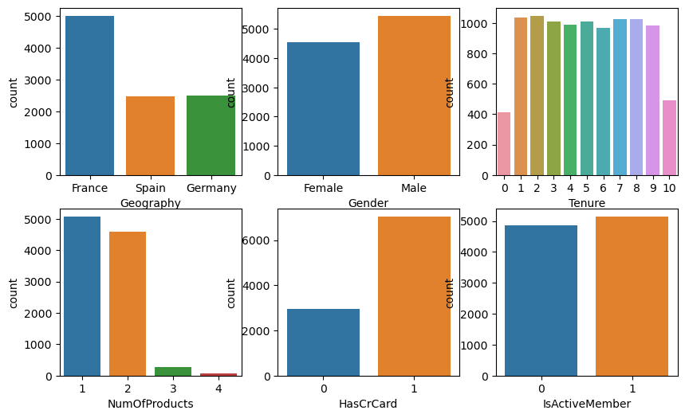

```python
# Explore categorical variables
i=1
plt.figure(figsize=(10,6))
for col in cat_cols:
    #print("Category: ", col)
    #print(df[col].value_counts(),'\n')
    plt.subplot(2,3,i)
    sns.countplot(x=col, data=df)
    i+=1
```

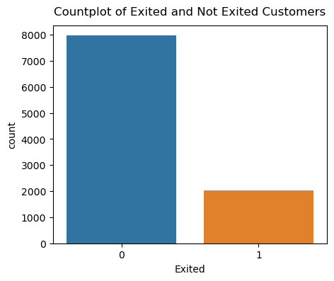

```python
# Check how balance the dataset is
plt.figure(figsize=(5,4))
sns.countplot(data=df, x='Exited')
plt.title("Countplot of Exited and Not Exited Customers", y=1.02)
plt.show()
```

There are about 4 times of negatives than positives. The dataset is not very balanced so accuracy score may not be the decisive metric. Other metrics should also be considered.

|  | CreditScore | Age | Balance | EstimatedSalary |
| --- | --- | --- | --- | --- |
| count | 10000.000000 | 10000.000000 | 10000.000000 | 10000.000000 |
| mean | 650.528800 | 38.921800 | 76485.889288 | 100090.239881 |
| std | 96.653299 | 10.487806 | 62397.405202 | 57510.492818 |
| min | 350.000000 | 18.000000 | 0.000000 | 11.580000 |
| 25% | 584.000000 | 32.000000 | 0.000000 | 51002.110000 |
| 50% | 652.000000 | 37.000000 | 97198.540000 | 100193.915000 |
| 75% | 718.000000 | 44.000000 | 127644.240000 | 149388.247500 |
| max | 850.000000 | 92.000000 | 250898.090000 | 199992.480000 |

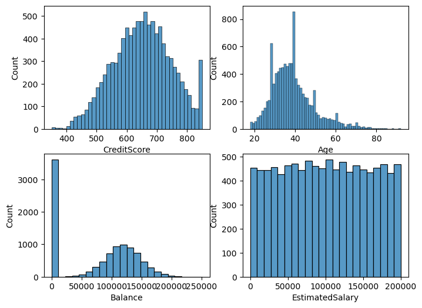

```python
# Explore numeric variables
display(df[num_cols].describe())

plt.figure(figsize=(8,6))
i=1
for col in num_cols:
    plt.subplot(2,2,i)
    sns.histplot(x=col, data=df)
    i+=1
```

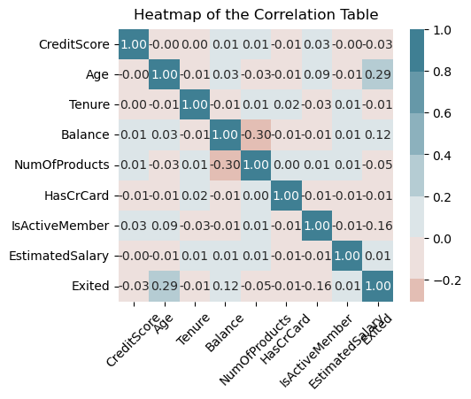

```python
# Correlation heatmap
plt.figure(figsize=(5,4))
sns.heatmap(df.iloc[:,3:].corr(),
            annot=True,
            fmt=".2f",
            center=0,
            cmap=sns.diverging_palette(20, 220, n=10))
plt.xticks(rotation=45)
plt.title("Heatmap of the Correlation Table", y=1.01)
plt.show()
```

The correlation heatmap doesn't indicates any strong linear relationship between "Exited" and any other variable. Desirably, there is no even moderate linear relationship between x variables, which indicates the absence of multilinearity.

# 2. Modeling

```python
# Extract x columns and the y column
X = df.iloc[:,3:-1]
y = df.iloc[:,-1]

print("Overview of X variables:")
display(X.head())
print("Overview of y:")
display(y.head())
```

```
Overview of X variables:
```

|  | CreditScore | Geography | Gender | Age | Tenure | Balance | NumOfProducts | HasCrCard | IsActiveMember | EstimatedSalary |
| --- | --- | --- | --- | --- | --- | --- | --- | --- | --- | --- |
| 0 | 619 | France | Female | 42 | 2 | 0.00 | 1 | 1 | 1 | 101348.88 |
| 1 | 608 | Spain | Female | 41 | 1 | 83807.86 | 1 | 0 | 1 | 112542.58 |
| 2 | 502 | France | Female | 42 | 8 | 159660.80 | 3 | 1 | 0 | 113931.57 |
| 3 | 699 | France | Female | 39 | 1 | 0.00 | 2 | 0 | 0 | 93826.63 |
| 4 | 850 | Spain | Female | 43 | 2 | 125510.82 | 1 | 1 | 1 | 79084.10 |

```
Overview of y:
```

```
0    1
1    0
2    1
3    0
4    0
Name: Exited, dtype: int64
```

```python
# One-hot encoding categorical variables
X = pd.get_dummies(X)

# Split train and test datset
X_train, X_test, y_train, y_test = model_selection.train_test_split(X, y, test_size=0.3, stratify=y, random_state=117)

# Standardization
scaler = RobustScaler()
scaler.fit(X_train[:])
X_train[:] = scaler.transform(X_train[:])
scaler.fit(X_test[:])
X_test[:] = scaler.transform(X_test[:])
```

```python
# Define a function to check metrics for each model
def get_metrics(y_test, y_pred, model_name):
    acc = metrics.accuracy_score(y_test, y_pred)
    rec = metrics.recall_score(y_test, y_pred)
    prec = metrics.precision_score(y_test, y_pred)
    fpr, tpr, thresholds = metrics.roc_curve(y_test, y_pred)
    auc = metrics.auc(fpr, tpr)
    print(f'{model_name}:')
    print("\tAccuracy Score:", round(acc,3))
    print("\tRecall Score:", round(rec,3))
    print("\tPrecision Score:", round(prec,3))
    print("\tArea Under the Curve:", round(auc,3))
    print("\nConfusion Matrix and ROC Curve:")
    metrics.ConfusionMatrixDisplay.from_predictions(y_test, y_pred)
    metrics.RocCurveDisplay.from_predictions(y_test, y_pred)

    return acc, rec, prec, auc
```

## i. Logistic Regression

```
Logistic Regression:
	Accuracy Score: 0.809
	Recall Score: 0.293
	Precision Score: 0.559
	Area Under the Curve: 0.617

Confusion Matrix and ROC Curve:
```

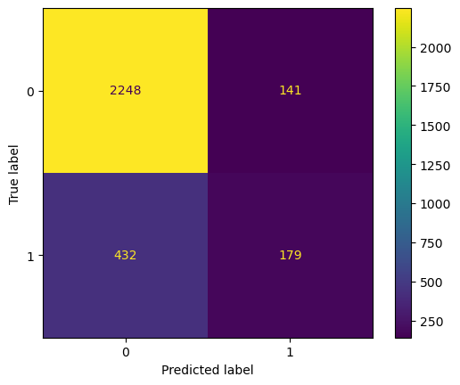

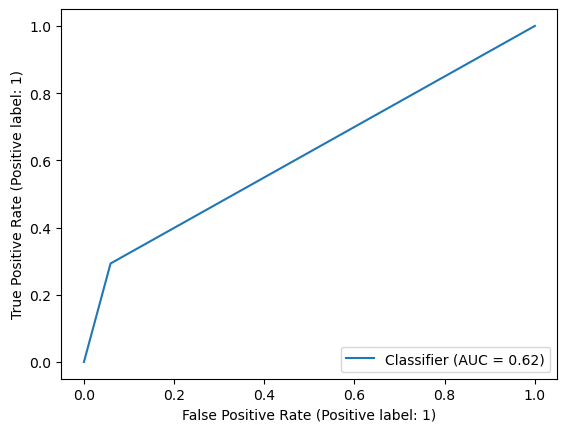

```python
logistic_model = LogisticRegression()

logistic_model.fit(X_train, y_train)
y_pred = logistic_model.predict(X_test)

lg_acc, lg_rec, lg_prec, lg_auc = get_metrics(y_test, y_pred, "Logistic Regression")
```

## ii. KNN

```
K Nearest Neighbor:
	Accuracy Score: 0.83
	Recall Score: 0.411
	Precision Score: 0.624
	Area Under the Curve: 0.674

Confusion Matrix and ROC Curve:
```

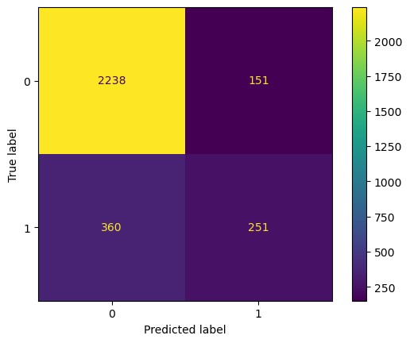

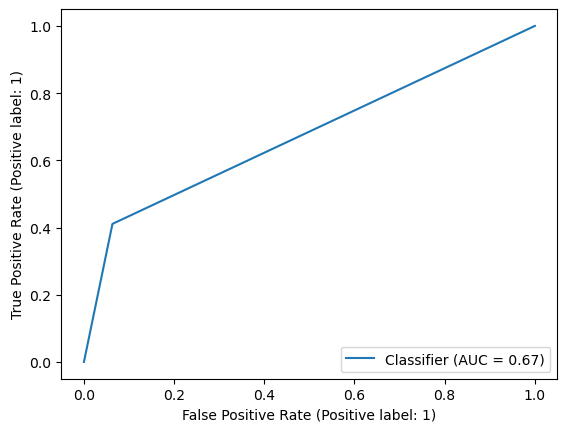

```python
knn_model = KNeighborsClassifier()

knn_model.fit(X_train, y_train)
y_pred = knn_model.predict(X_test)

knn_acc, knn_rec, knn_prec, knn_auc = get_metrics(y_test, y_pred, "K Nearest Neighbor")
```

## iii. Random Forest

```
Random Forest:
	Accuracy Score: 0.856
	Recall Score: 0.455
	Precision Score: 0.737
	Area Under the Curve: 0.707

Confusion Matrix and ROC Curve:
```

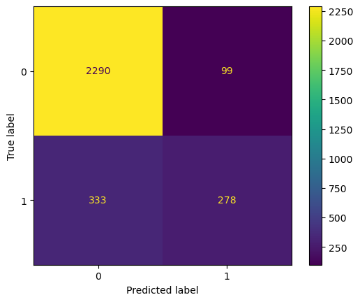

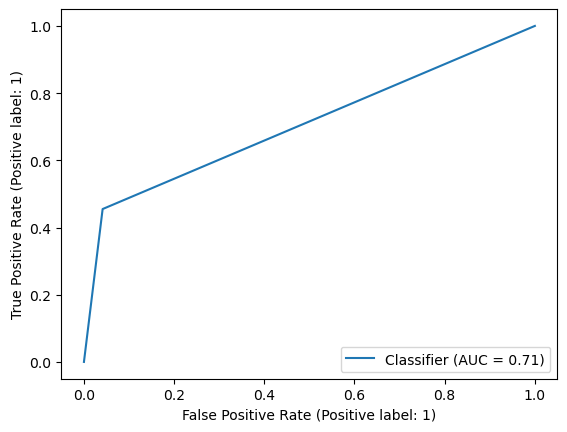

```python
rf_model = RandomForestClassifier()

rf_model.fit(X_train, y_train)
y_pred = rf_model.predict(X_test)

rf_acc, rf_rec, rf_prec, rf_auc = get_metrics(y_test, y_pred, "Random Forest")
```

# 3. Compare and Analyze Model Results

```python
model_metrics = pd.DataFrame({"Logistic Regression":[lg_acc, lg_rec, lg_prec, lg_auc],
                              "K Nearest Neighbor":[knn_acc, knn_rec, knn_prec, knn_auc],
                              "Random Forest":[rf_acc, rf_rec, rf_prec, rf_auc]},
                             index=['Accuracy','Recall','Precision', "AUC"])
model_metrics.round(2)
```

|  | Logistic Regression | K Nearest Neighbor | Random Forest |
| --- | --- | --- | --- |
| Accuracy | 0.81 | 0.83 | 0.86 |
| Recall | 0.29 | 0.41 | 0.45 |
| Precision | 0.56 | 0.62 | 0.74 |
| AUC | 0.62 | 0.67 | 0.71 |

Based on the model performance metrics table above, Random Forest outstrips Logistic Regression and KNN in terms of accuracy score, recall score, precision score, and AUC. Therefore, undoubtedly, Random Forest should be the best fit to predict customer churn.

Leaving aside the fact that Random Forest has better performance in every metric, when predicting customer churning rate, if the data is randomly sampled, there would naturally be much more negatives (not churn) than positives (churn). Therefore accuracy should not be considered solely. In addition, the business purpose behind the model is to identify customers who are of a higher probability to churn and then perform promotion or advertisement on this specific customer segment in order to lower the overall customer churning rate. It means that we care more about the true positive rate, i.e. recall, since we prefer a customer segment pool in which more churn-likely customers are identified, even though the amount of the pool may be relatively larger.

# 4. Insights from the Predictions

```python
# Get the predictions from the Random Forest Model
y_pred = rf_model.predict(X_test)
y_pred = pd.Series(y_pred, name="Predicted_Exit")

# Attach the predictions to the dataframe
results = pd.concat([df.iloc[:,3:], y_pred], axis=1)
results.head()
```

|  | CreditScore | Geography | Gender | Age | Tenure | Balance | NumOfProducts | HasCrCard | IsActiveMember | EstimatedSalary | Exited | Predicted_Exit |
| --- | --- | --- | --- | --- | --- | --- | --- | --- | --- | --- | --- | --- |
| 0 | 619 | France | Female | 42 | 2 | 0.00 | 1 | 1 | 1 | 101348.88 | 1 | 0.0 |
| 1 | 608 | Spain | Female | 41 | 1 | 83807.86 | 1 | 0 | 1 | 112542.58 | 0 | 0.0 |
| 2 | 502 | France | Female | 42 | 8 | 159660.80 | 3 | 1 | 0 | 113931.57 | 1 | 0.0 |
| 3 | 699 | France | Female | 39 | 1 | 0.00 | 2 | 0 | 0 | 93826.63 | 0 | 0.0 |
| 4 | 850 | Spain | Female | 43 | 2 | 125510.82 | 1 | 1 | 1 | 79084.10 | 0 | 0.0 |

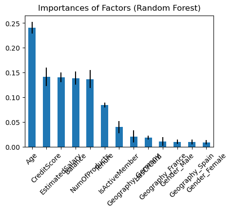

```python
# Get the Importances and their std for each input variable
importances= rf_model.feature_importances_
std = np.std([tree.feature_importances_ for tree in rf_model.estimators_], axis=0)

# Visualize the Importance information
feature_names = X.columns
plt.figure(figsize=(5,3.5))
forest_importances = pd.Series(importances, index=feature_names)
forest_importances = forest_importances.sort_values(ascending=False)
forest_importances.plot.bar(forest_importances, yerr=std)
plt.xticks(rotation=45)
plt.title("Importances of Factors (Random Forest)", y=1.01)
plt.show()
```

The importance plot indicates that customer age is the most important factor when predicting customer's churning rate. Besides, the estimated salary of the customer, the credit score of the customer, the balance amount in the customer's account, and the number of products the customer purchased are also important.

```python
results[results['Exited']==0]['Age'].mean()
```

```
37.40838879819164
```

## 1. Dive into Age

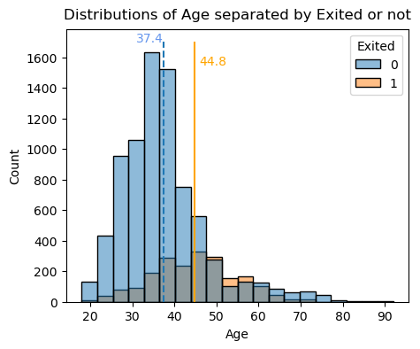

```python
# The distribution of Age
plt.figure(figsize=(5,4))
sns.histplot(x="Age", data=results, hue='Exited', bins=20)
plt.vlines(results[results['Exited']==0]['Age'].mean(), 0, 1700, linestyles='dashed')
plt.vlines(results[results['Exited']==1]['Age'].mean(), 0, 1700, colors='orange')
plt.text(31, 1700, round(results[results['Exited']==0]['Age'].mean(),1), c='cornflowerblue')
plt.text(46, 1550, round(results[results['Exited']==1]['Age'].mean(),1), c='orange')
plt.title("Distributions of Age separated by Exited or not", y=1.01)
plt.show()
```

The mean age of customers who churned is 44.8 while the number is 37.4 for customers who did not churn. The distributions of churned and unchurned customers imply that customers whoes age ranges from 30-40 are less likely to churn while customers whose age is higher than 50 are more likely to churn.

## ii. Dive into Estimated Salary

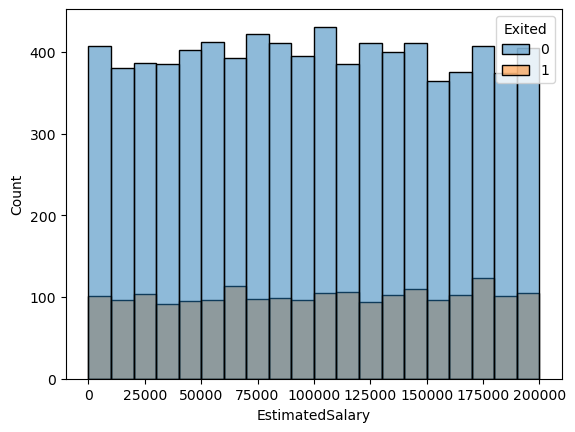

```python
# The distribution of Salary
sns.histplot(x="EstimatedSalary", data=results, hue='Exited', bins=20)
plt.show()
```

The distribution plot does not indicate a significant difference in distributions of estimated salary for churned and unchurned customers.

## ii. Dive into Credit Scores

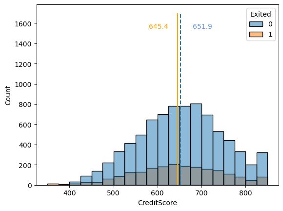

```python
# The distribution of Credit Scores
sns.histplot(x="CreditScore", data=results, hue='Exited', bins=20)
plt.vlines(results[results['Exited']==0]['CreditScore'].mean(), 0, 1700, linestyles='dashed')
plt.vlines(results[results['Exited']==1]['CreditScore'].mean(), 0, 1700, colors='orange')
plt.text(680, 1550, round(results[results['Exited']==0]['CreditScore'].mean(),1), c='cornflowerblue')
plt.text(580, 1550, round(results[results['Exited']==1]['CreditScore'].mean(),1), c='orange')
plt.show()
```

## iii. Dive into Balance

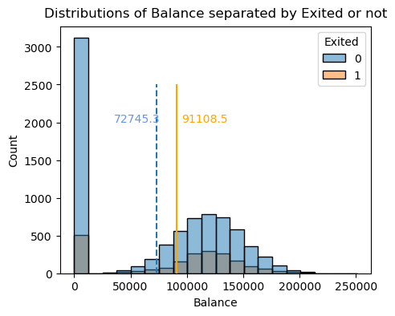

```python
# The distribution of Balance
plt.figure(figsize=(5,4))
sns.histplot(x="Balance", data=results, hue='Exited', bins=20)
plt.vlines(results[results['Exited']==0]['Balance'].mean(), 0, 2500, linestyles='dashed')
plt.vlines(results[results['Exited']==1]['Balance'].mean(), 0, 2500, colors='orange')
plt.text(35000, 2000, round(results[results['Exited']==0]['Balance'].mean(),1), c='cornflowerblue')
plt.text(95000, 2000, round(results[results['Exited']==1]['Balance'].mean(),1), c='orange')
plt.title("Distributions of Balance separated by Exited or not", y=1.01)
plt.show()
```

## iv. Dive into Number of Items Purchased

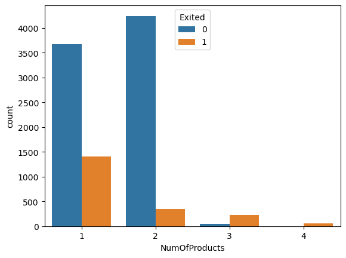

```python
# The distribution of NumOfProducts
sns.countplot(x="NumOfProducts", data=results, hue='Exited')
plt.show()
```